# Global Emissions and GDP

MEDS

R

environment modeling

statistics

data science

Exploring the decoupling effects accross countries

Author

[Aakriti Poudel](https://aakriti-poudel-chhetri.github.io/)

Published

December 3, 2025

# Introduction

Can a country reduce emissions while growing its GDP? This question has gained significant attention in recent years as all countries globally are trying to achieve the economic development with maintaining environmental sustainability. In this assignment, we examine global power-sector emissions and GDP data from more than 200 countries to explore whether sustained economic growth can occur alongside meaningful emission reductions.

# Background

Economic growth and greenhouse gas emissions have traditionally been closely linked. The increase in GDP is often accompanied by higher emissions rate due to higher energy consumption, increasing industrial activities and infrastructure growth. However, the recent trend shows that some countries are beginning to break this pattern. By analyzing emissions alongside GDP, we can identify which countries are achieving ‘decoupling’ where economic growth increases without a corresponding rise in emissions. This decoupling can be a result of combination of multiple factors such as clean energy, improvements in energy efficiency, technological innovation and effective climate policies. The study of these trends provides valuable insights into how countries can pursue sustainable development, balancing economic progress with environmental responsibility. It can serve as a guide for other nations who are aiming to reduce their carbon footprint while maintaining their economic growth.

# Set Up

First, let’s load all the required libraries.

```r
set.seed(123)

# Load libraries
library(tidyverse)
library(dagitty)
library(ggdag)
library(janitor)
library(MASS)
library(modelsummary)
library(kableExtra)
library(knitr)
library(scales)
```

# Directed Acyclic Graph (DAG)

| Variables | Abbreviation |
| --- | --- |
| Economy | EC |
| Emissions Quantity | EQ |
| Energy Use | EU |
| Technology | T |
| Decoupling Year | DY |
| GDP Growth | GDP |

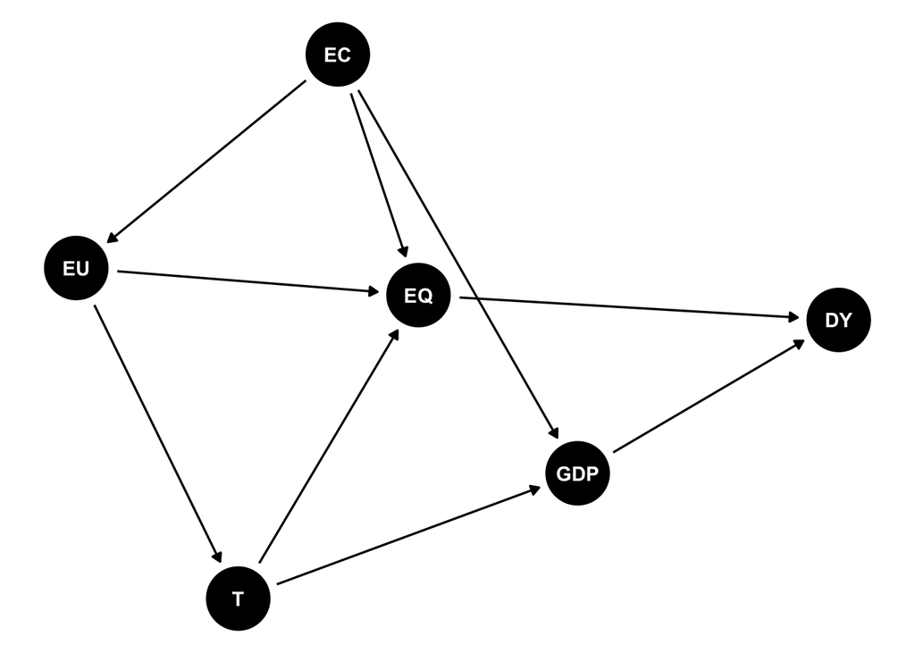

# Data Description

Here, we will work with the following data sets:

## GDP data

The data set comes from the [World Bank](https://data.worldbank.org/indicator/NY.GDP.MKTP.CD?locations=1W) and uses the indicator NY.GDP.MKTP.CD, which reports national gross domestic product (GDP) in current U.S. dollars. It measures the total value of all goods and services produced in a country in a given year, converted into U.S. dollars using that year’s official exchange rate. As it is a ‘current’ GDP, the values reflect the prices and exchange rates of the respective year, not adjusted for inflation or purchasing-power differences.

## Global emissions data

This data set is retrieved from [Climate TRACE](https://climatetrace.org/data). It provides a detailed, open-access global inventory of greenhouse gas and air pollution emissions. It aggregates data from hundreds of millions of emission sources worldwide including power plants, industrial facilities, transportation, agriculture, and more, allowing emissions to be broken down by country, sector, sub-sector and time period. The data cover emissions over multiple years, starting from 2015 for annual country-level data, and with monthly and source level records available since 2021 .

In this analysis, we focus specifically on the power sector data, which provides detailed emissions estimates, allowing us to examine trends and impacts within one of the largest sources of global greenhouse-gas emissions.

# Hypotheses Statement

**Question:** To what extent GDP and global emissions account for the number of years countries achieve by decoupling between economic growth and emissions?

**Null Hypothesis (H0):** There is no significant relationship between the GDP and global emissions, and the number of decoupling years.

**Alternative Hypothesis (HA):** There is a significant relationship between the GDP and global emissions, and the number of decoupling years.

# Data Simulation

Before fitting the actual data to the model, we will simulate data to conform the Negative Binomial Model. This will help us understand the model and ensure that it behaves as expected prior to applying it to real world data set.

The statistical notation for the Negative Binomial Model.

$$\begin{align}
\text{CountOutcome} &\sim NegativeBinomial(\mu, \theta) \\
log(\mu) &= \beta_0 + \beta_1 \text{Predictor}
\end{align}
\\$$

model <- glm.nb(count_outcome ~ predictor, data = my_data)

## Set up parameters and test the model

```r
# Set the parameters
n <- 10000 # Data set size
beta0 <- 0.6
beta1 <- 1.8
r <- 2 # Dispersion

# Uniform distribution between 1 and 10
x <- runif(n, min = 1, max = 10)

# Calculate mean (mu) using the Negative Binomial link function (log link)
mu <- exp(beta0 + beta1 * x)

# Simulate the dependent variable (y)
y <- rnbinom(n = n, mu = mu, size = r)

# Create a data set
my_data <- data.frame(x, y)

# Fit a negative binomial model
negbinomial <- glm.nb(y ~ x, data = my_data)
```

## Visualize the model

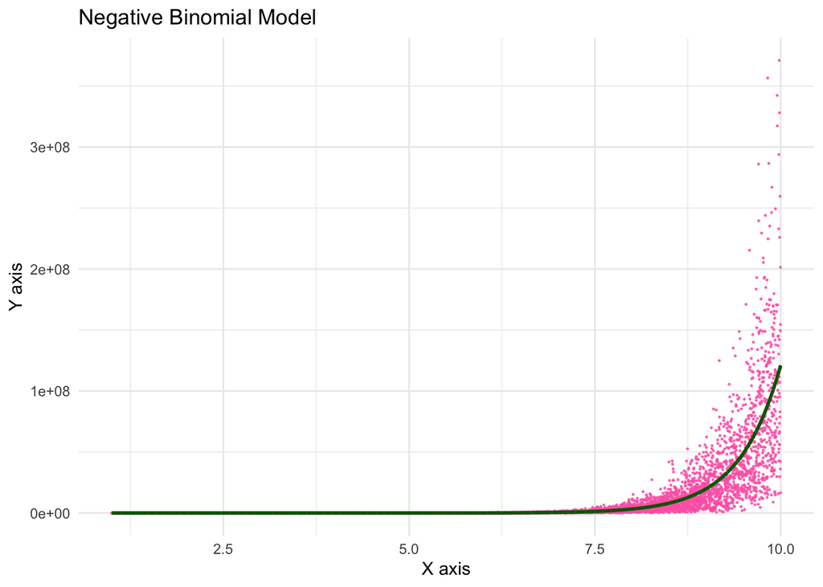

Figure 2: Negative Binomial Model

```r
# Create predictions from the model
my_data$prediction <- predict(negbinomial, type = "response")

# Simple scatter plot with fitted line
ggplot(my_data, aes(x = x, y = y)) +
  geom_point(alpha = 0.8, size = 0.2, color = "hotpink") +
  geom_line(aes(y = prediction), color = "darkgreen", linewidth = 1) +
  labs(title = "Negative Binomial Model",
       x = "X axis",
       y = "Y axis") +
  theme_minimal()
```

## Extract coefficient of the tested model

```r
# Summarize the model in a table
negbinomial_summary <- list ("Negative Binomial" = glm.nb(y ~ x, data = my_data))
modelsummary(negbinomial_summary)
```

|  | Negative Binomial |
| --- | --- |
| (Intercept) | 0.589 |
|  | (0.017) |
| x | 1.802 |
|  | (0.003) |
| Num.Obs. | 10000 |
| AIC | 226769.7 |
| BIC | 226791.3 |
| Log.Lik. | -113381.836 |
| F | 425984.119 |
| RMSE | 13952620.72 |

Here, let’s check the dispersion parameter that controls the amount of over dispersion in the data.

```r
# Calculate the dispersion parameter
estimated_theta <- negbinomial$theta
print(paste0("Estimated Theta: ", round(estimated_theta, 4)))
```

```
[1] "Estimated Theta: 2.0202"
```

The coefficients from our simulation are almost same as the ones we used initially. This tells us that our model is set up correctly and uses the right negative binomial settings.

| Coefficients | Set up | Simulated |
| --- | --- | --- |
| beta0 | 0.6 | 0.58 |
| beta1 | 1.8 | 1.80 |
| theta | 2 | 2.00 |

Now, we can run the negative binomial regression on our real data.

# GDP and Emissions Data

## Read the GDP and emissions data set

```r
# Read the data for power sector
electricity <- read_csv(here::here('posts', '2025-12-global-emissions-gdp', 'data', 'power', 'DATA', 'electricity-generation_country_emissions_v5_1_0.csv'),
                        na = c(" ", "0", "0.0", "NA")) %>%
  clean_names()

heat_plants <- read_csv(here::here('posts', '2025-12-global-emissions-gdp', 'data', 'power', 'DATA', 'heat-plants_country_emissions_v5_1_0.csv'),
                        na = c(" ", "0", "0.0", "NA")) %>%
  clean_names()

other_energy <- read_csv(here::here('posts', '2025-12-global-emissions-gdp', 'data', 'power', 'DATA', 'other-energy-use_country_emissions_v5_1_0.csv'),
                        na = c(" ", "0", "0.0", "NA")) %>%
  clean_names()

# Read the GDP data set
gdp <- read_csv(here::here('posts', '2025-12-global-emissions-gdp', 'data', 'API_NY.GDP.MKTP.CD_DS2_en_csv_v2_280632', 'API_NY.GDP.MKTP.CD_DS2_en_csv_v2_280632.csv'),
                        na = c(" ", "NA"),
                skip = 4) %>%
  clean_names()
```

## Data wrangling

**Combine and clean power sub sector data for yearly analysis.** - We combine data from electricity, heat plants, and other energy sub-sectors to create a clean, year-wise dataset. This provides clear insights into trends and patterns in energy production, enabling meaningful comparisons across countries over time.

```r
# Combine all three sub sector data sets
power <- bind_rows(electricity, heat_plants, other_energy)

# Make a new column 'year' to segregate according to year
power_year <- power %>%
  mutate(year = year(power$start_time))

# Rename the column and filter year 2025
power_year_cleaned <- power_year %>%
  # Rename the column to match with gdp dataset
  rename(country_code = iso3_country) %>%
  # Filter out the year 2025 (no data of 2025 available for GDP)
  filter(year != 2025)
```

**Clean and reshape GDP data for further analysis.** - We clean and reshape the GDP dataset into a long format to for annual analysis. This restructure allows easy integration with other datasets and helps accurate, time-based comparisons.

```r
# Convert data to long format
gdp_long<- gdp %>%
  # Drop 'x70' column and columns from x1960 to x2014
  dplyr::select(-x70, -x1960:-x2014) %>%
  pivot_longer(cols = starts_with("x"),
               names_to = "year",
               values_to = "gdp_values") %>%
  # Remove 'x' from the 'year' string
  mutate(year = stringr::str_replace(year, pattern = "x", replacement = ""),
  # Convert the resulting string to a numeric data type
  year = as.numeric(year))
```

**Combine power sub sector and GDP data for a streamlined structure and easy analysis.** - By combining power sub-sector and GDP data, we create a dataset that has comprehensive details of energy-related emissions in relation to GDP across countries and over time.

```r
# Join the data frame and reorder the columns
power_gdp <- power_year_cleaned %>%
  left_join(gdp_long, by = c("country_code", "year")) %>%
  # Filter rows where 'country_name' column is empty
  filter(!is.na(country_name), country_name != "") %>%
  # Reorder the columns by position
  dplyr::select(13, 1, 12, everything())
```

## Identify ten highest emissions countries from year 2015 to 2024

### Calculate top 10 emitting countries

Here, we identify the ten countries with the highest emission levels globally over the past decade (2015–2024). This will make it easier to observe trends and interpret the decoupling year when we calculate it later.

```r
# Calculate the mean emissions of countries for each year (2015 - 2024)
power_gdp_mean <- power_gdp %>%
  drop_na(emissions_quantity) %>%
  group_by(country_name, year) %>%
  summarize(mean = mean(emissions_quantity),
            .groups = 'drop') %>%
  arrange(desc(mean))

# Top 10 countries by overall mean emissions for all years
top_10_emitter <- power_gdp_mean %>%
  group_by(country_name) %>%
  summarize(overall_mean = mean(mean), .groups = 'drop') %>%
  arrange(desc(overall_mean)) %>%
  slice_head(n = 10)

# Filter to keep only top 10 countries
power_gdp_mean_top10 <- power_gdp_mean %>%
  filter(country_name %in% top_10_emitter$country_name)
```

### Visualize top ten 10 emitting countries

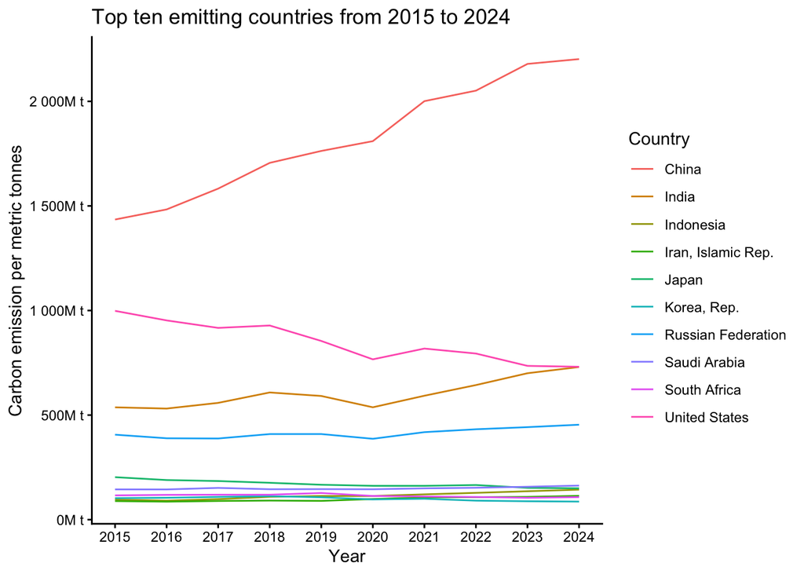

Figure 3: The plot shows the annual mean carbon emissions from 2015 to 2024 for the ten highest-emitting countries. This allows us to visualize trends over time.

```r
# Visualize top ten emitting countries
 ggplot(power_gdp_mean_top10, aes(x = year, y = mean, color = country_name)) +
  geom_line() +
  scale_x_continuous(breaks = seq(2015, 2024, by = 1)) +
  scale_y_continuous(labels = scales::label_number(scale = 1e-6, suffix = "M t")) +
  labs(x = "Year",
       y = "Carbon emission per metric tonnes",
       title = "Top ten emitting countries from 2015 to 2024",
       color = "Country") +
  theme_classic()
```

Figure 3 shows that the highest‐emitting countries are China, United States, India, Russia, Japan, Saudi Arabia, Indonesia, South Africa, Korea and Iran.

## Identify top ten countries with increasing GDP from year 2015 to 2024

### Calculate top ten countries with increasing GDP

We again identify the ten countries that have experienced increasing GDP over the past decade, from 2015 to 2024. This helps us highlight consistent economic growth trends and examine their potential impacts on energy consumption.

```r
# Calculate the mean emissions of countries for each year (2015 - 2024)
power_gdp_mean <- power_gdp %>%
  drop_na(gdp_values) %>%
  group_by(country_name, year) %>%
  summarize(mean = mean(gdp_values),
            .groups = 'drop') %>%
  arrange(desc(mean))

# Top 10 countries by overall mean emissions for all years
top_10_gdp <- power_gdp_mean %>%
  group_by(country_name) %>%
  summarize(overall_mean = mean(mean), .groups = 'drop') %>%
  arrange(desc(overall_mean)) %>%
  slice_head(n = 10)

# Filter to keep only top 10 countries
power_gdp_mean_gdp <- power_gdp_mean %>%
  filter(country_name %in% top_10_gdp$country_name)
```

### Visualize top ten countries with increasing GDP

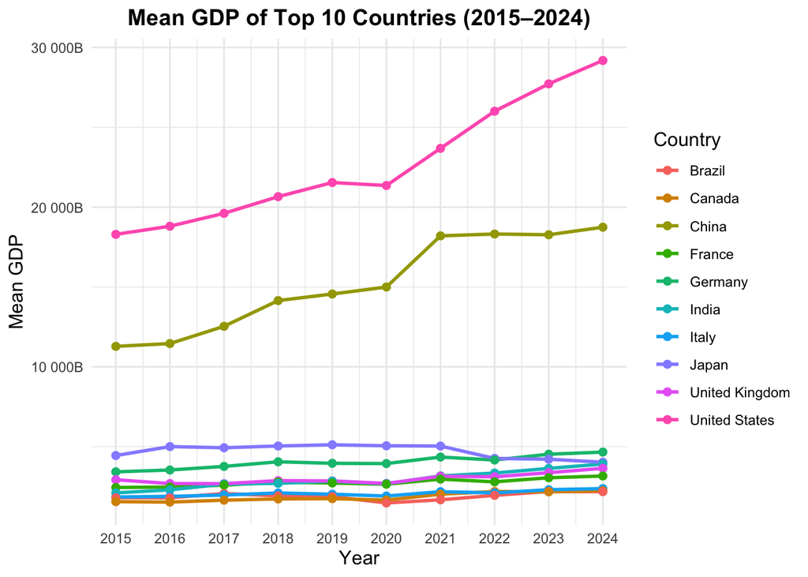

Figure 4: The plot shows the annual mean GDP from 2015 to 2024 for the ten countries with the highest GDP. This allows us to visualize economic growth trends over time.

```r
# Visualize top ten countries with increasing GDP
suppressWarnings({
  ggplot(power_gdp_mean_gdp, aes(x = year, y = mean, color = country_name)) +
    geom_line(linewidth = 1) +  # use the new correct argument
    geom_point(size = 2) +      # points still use size
    scale_x_continuous(breaks = seq(2015, 2024, by = 1)) +
    scale_y_continuous(labels = scales::label_number(scale = 1e-9, suffix = "B")) +
    labs(
      title = "Mean GDP of Top 10 Countries (2015–2024)",
      x = "Year",
      y = "Mean GDP",
      color = "Country"
    ) +
    theme_minimal() +
    theme(
      plot.title = element_text(hjust = 0.5, size = 14, face = "bold"),
      axis.title = element_text(size = 12),
      legend.title = element_text(size = 12)
    )
})
```

Figure 4 indicates that the countries with the highest GDP are United States, China, Japan, Germany, the United Kingdom, India, France, Italy, Brazil and Canada.

## Calculate GDP and emissions changes

We calculate the total GDP and carbon emissions for each country by year and computed the corresponding annual percentage changes. This provides insights into how economic growth and emissions have changed over time for each country.

```r
# Aggregate GDP and emissions by country and year
country_totals <- power_gdp %>%
  group_by(country_name, country_code, year) %>%
  summarize(total_emissions = sum(emissions_quantity, na.rm = TRUE),
            gdp_values = first(gdp_values),
            .groups = 'drop')

# Calculate annual changes in GDP and emissions
annual_changes <- country_totals %>%
  arrange(country_code, year) %>%
  group_by(country_name, country_code) %>%
  mutate(emissions_pct_change = (total_emissions - lag(total_emissions)) / lag(total_emissions) * 100,
         gdp_pct_change = (gdp_values - lag(gdp_values)) / lag(gdp_values) * 100) %>%
  ungroup()
```

### Identify countries with increased GDP and decreased emissions

This analysis gives countries where GDP increased while carbon emissions decreased. It highlights instances of environmental-economic decoupling.This provides a clear view of successful decoupling cases.

```r
# Find the cases where emissions decreased while GDP increased
decoupling <- annual_changes %>%
  filter(emissions_pct_change < 0 & gdp_pct_change > 0) %>%
  dplyr::select(country_name, year, emissions_pct_change, gdp_pct_change)

# Find countries where emissions decreased while GDP increased
decoupling_case <- decoupling %>%
  group_by(country_name) %>%
  summarize(decoupling_years = n(),
            avg_emission_reduction = mean(emissions_pct_change),
            avg_gdp_growth = mean(gdp_pct_change),
            .groups = 'drop') %>%
  arrange(desc(decoupling_years))
```

### Visualize top ten countries with decoupling effects

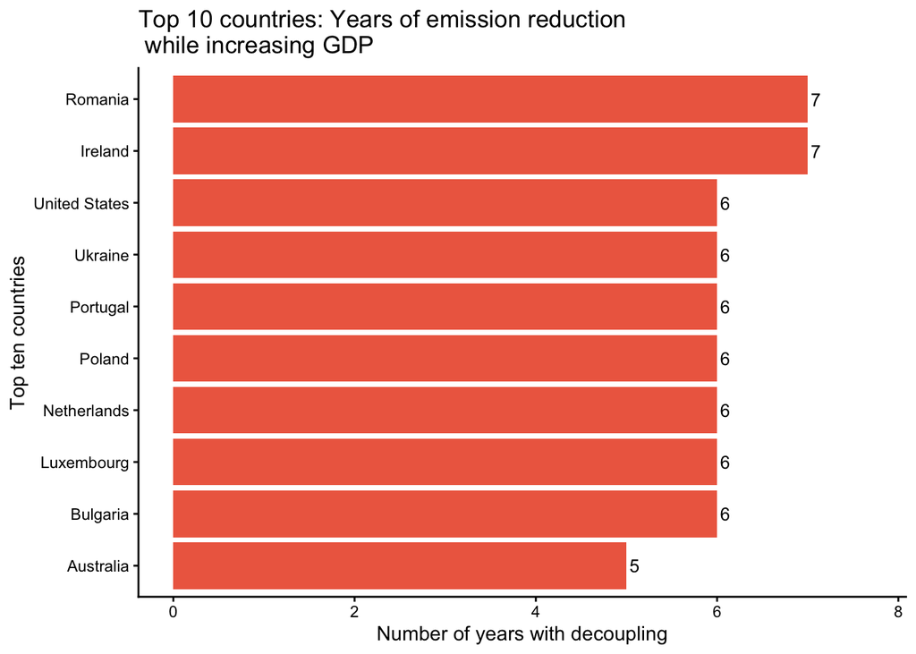

Figure 5: The plot shows the top ten countries with the most years where GDP increased and carbon emissions decreased. Each bar represents the number of years a country experienced this decoupling effect.

```r
# Filter the top ten countries with decoupling effects
decoup_ten <- decoupling_case %>%
  arrange(desc(decoupling_years)) %>%
  slice_head(n = 10)

# Plot a graph for top ten countries
ggplot(decoup_ten, aes(x = reorder(country_name, decoupling_years),
                       y = decoupling_years)) +
  geom_col(fill = 'coral2') +
  geom_text(aes(label = decoupling_years), hjust = -0.3, size = 3.5) +
  coord_flip() +
  theme_classic() +
  labs(x = "Top ten countries",
    y = "Number of years with decoupling",
    title = "Top 10 countries: Years of emission reduction\n while increasing GDP") +
  ylim(0, max(decoup_ten$decoupling_years) * 1.1)
```

Figure 5 highlights the countries that achieved the decoupling case: Ireland, Romania, Bulgaria, Luxembourg, the Netherlands, Poland, Portugal, Ukraine, United States and Australia.

### Interpretation of data analysis

# Fit GDP and emissions data into a model

We fit GDP and emissions data into the negative binomial model to quantify the relationship between economic growth and carbon emissions. This allows us to understand whether changes in GDP are associated with changes in emissions and to make predictions or draw inferences based on the model.

$$\begin{align}
\text{decoupling\_years} &\sim \text{NegativeBinomial}(\mu, \theta) \\
\log(\mu) &= \beta_0 + \beta_1\,\text{avg\_emission\_reduction} + \beta_2\,\text{avg\_gdp\_growth}
\end{align}$$

Now, let’s fit our decoupling years in the negative binomial model.

```r
# Fit the model
nb_model <- glm.nb(decoupling_years ~ avg_gdp_growth + avg_emission_reduction,
                data = decoupling_case)
```

We extract the model coefficients and display them in a table to facilitate interpretation and comparison.

```r
# Extract coefficient summary
coef_table <- coef(summary(nb_model))

# Create a clean data frame
results_table <- data.frame(
  Predictor = c("Intercept", "Average GDP Growth", "Average Emission Reduction"),
  Estimate = coef_table[, "Estimate"],
  SE = coef_table[, "Std. Error"],
  `z value` = coef_table[, "z value"],
  `p value` = coef_table[, "Pr(>|z|)"])

# Create pretty table
kable(results_table,
      digits = 4,
      col.names = c("Predictor", "Estimate (β)", "Std. Error", "z-value", "p-value"),
      caption = "Coefficients of Negative Binomial Regression",
      align = c("l", "r", "r", "r", "r")) %>%
  kable_styling(bootstrap_options = c("striped", "hover", "condensed"),
                full_width = FALSE,
                position = "center") %>%
  row_spec(0, bold = TRUE, background = "#f0f0f0")
```

Coefficients of Negative Binomial Regression

|  | Predictor | Estimate (β) | Std. Error | z-value | p-value |
| --- | --- | --- | --- | --- | --- |
| (Intercept) | Intercept | 1.0423 | 0.0895 | 11.6431 | 0.0000 |
| avg_gdp_growth | Average GDP Growth | -0.0141 | 0.0075 | -1.8903 | 0.0587 |
| avg_emission_reduction | Average Emission Reduction | -0.0090 | 0.0046 | -1.9407 | 0.0523 |

We extract the estimated theta to evaluate the degree of dispersion and the precision of the estimate.

*Note:* In the negative binomial model, the dispersion parameter theta captures the degree of over dispersion in the data, how much the variance exceeds the mean. A higher theta indicates lower overdispersion, whereas a lower theta suggests stronger overdispersion.

```r
# Calculate value of theta
theta_value <- nb_model$theta
theta_value
```

```
[1] 59399.28
```

## Interpretation of the Coefficients

Here, we will interpret the coefficients of our model. The coefficients of the negative binomial regression show that both average GDP growth and average emission reduction have weak relationships with the decoupling year.

The intercept coefficient of 1.0423 is statistically significant at p < 0.001 and represents the expected log count of decoupling year when both GDP growth and emission reduction are at zero. This means that when both GDP growth and emission reduction are zero, the expected number of decoupling years is ~ 2.84.

The coefficient for average GDP growth is -0.0141, and its p-value (0.0587) shows that this relationship is not strong enough to be considered statistically significant at the 5% level. This negative coefficient suggests that for every one unit increase in average GDP growth, the expected log count of decoupling years decreases by 0.0141, when emission reduction is held constant.

The coefficient for average emission reduction is -0.0090, which is marginally significant at p = 0.0523. This indicates that for every one unit increase in emission reduction, the expected log count of decoupling year decreases by 0.0090.

# Create prediction data for GDP and emissions

We create a prediction grid for GDP growth and average emission reduction, then use the fitted negative binomial model to generate prediction and their standard errors. Using these, we construct 95% confidence intervals, providing a range of predicted values for each cases.

```r
# Create a prediction grid
prediction_grid <- expand_grid(
  avg_gdp_growth = seq(min(decoupling_case$avg_gdp_growth),
                       max(decoupling_case$avg_gdp_growth),
                       length.out = 50),
  avg_emission_reduction = mean(decoupling_case$avg_emission_reduction))

# Generate predictions and standard errors on link scale
prediction_se <- predict(nb_model,
                     newdata = prediction_grid,
                     type = "link",
                     se.fit = TRUE)

# Construct confidence intervals
prediction_ci <- prediction_grid %>%
  mutate(log_mu = prediction_se$fit,
         log_mu_se = prediction_se$se.fit,
    # Calculate 95% CI on link scale using ±1.96 SE
    log_mu_lwr = log_mu - 1.96 * log_mu_se,
    log_mu_upr = log_mu + 1.96 * log_mu_se,
    # Transform from link scale (log) to response scale (counts)
    mu = exp(log_mu),
    mu_lwr = exp(log_mu_lwr),
    mu_upr = exp(log_mu_upr))
```

We should note that the prediction grid creates a set of hypothetical scenarios to make predictions from the model. For GDP growth, we use the minimum and maximum values to cover the full observed range to see how predictions change from low to high GDP growth. For emission reduction, we use the average value to keep it constant to focus on how changes in GDP growth affect the predicted outcome.

## Visualize the model prediction

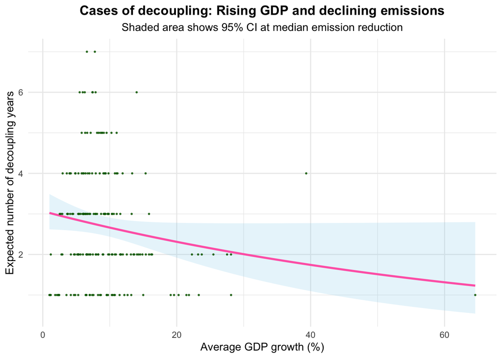

Figure 6: The plot visualizes the model predictions for the number of decoupling years as GDP increases and emission decreases. The pink line shows the predicted values of declining emissions, the shaded blue area represents the 95% confidence interval at the mean emission reduction, and the green points indicate the observed decoupling cases for each country.

```r
# Plot with single ribbon
ggplot() +
  # Add the 95% CI ribbon
  geom_ribbon(data = prediction_ci,
              aes(x = avg_gdp_growth, ymin = mu_lwr, ymax = mu_upr),
              fill = 'skyblue', alpha = 0.2) +
  # Plot the prediction line
  geom_line(data = prediction_ci,
            aes(x = avg_gdp_growth, y = mu),
            color = 'hotpink', linewidth = 1) +
  # Plot the observed decoupling cases
  geom_point(data = decoupling_case,
             aes(x = avg_gdp_growth, y = decoupling_years),
             color = 'darkgreen', alpha = 0.8, size = 0.4) +
  labs(title = 'Cases of decoupling: Rising GDP and declining emissions',
       subtitle = 'Shaded area shows 95% CI at median emission reduction',
       x = 'Average GDP growth (%)',
       y = 'Expected number of decoupling years') +
  theme_minimal() +
  theme(plot.title = element_text(hjust = 0.5, face = 'bold'),
        plot.subtitle = element_text(hjust = 0.5))
```

# Conclusion

We conclude that we fail to reject the null hypothesis.